# Sesion 11: Matrices de covarianzas

Juan Carlos Martinez-Ovando

Primavera 2017

# Distribuciones *Wishart* e *Inverse-Wishart*

## Definicion

El valor esperado de $\Sigma$ es
$$\mathbb{E}(\Sigma)=\nu S^{-1}.$$

Casos particulares:

- Cuando $p=1$ y $S=1$ la distribucion anterior se reduce a la distribucion $\chi^{2}$ con $\nu$ grados de libertad.
- Cuando $p=1$ la distribucion se reduce a la Gamma. Cuando $\nu=1$ obtenermos la distribucion exponenial.
- Si $\Sigma$ se distribuye Wishart, entonces $\Sigma^{-1}$ tiene distribucion *inverse-Wishart*.

En esta seccion visualizaremos las distribuciones marginales de los elementos de una matriz de varianzas y covarianzas con distribucion `inverse-Wishart`.

```
install.packages("MCMCpack")   # Wishart distribution
install.packages("actuar")     # inverse gamma distribution
install.packages("ggplot2")
```

```r
library(MCMCpack)
library(actuar)
```

```r
library(ggplot2)
```

## a) Hiperparametros de la distribucion inverse-Wishart

Primero, definimos los hiper-parametros de la distribucion. En este caso son dos, un parametro escalar para los `grados de libertad` y una matrix simetrica positivo definida, que es el parametro `matriz de escala`.

```r
S <- matrix(c(1,.3,.3,2),2,2)   # matriz de escala
nu  <- 5                          # grados de libertad
```

## b) Distribuciones marginales de las varianzas

```r
limits <- sapply(diag(S),
                function(x) qinvgamma(c(.01, .99),
                shape = nu/2, scale = x/2))
```

Podemos graficar las distribuciones marginales en la misma escala.

```r
limits <- c(min(limits[1, ]), max(limits[2, ]))
var <- seq(limits[1], limits[2], length = 501)
density <- do.call('c',
       lapply(diag(S),
         function(ss) dinvgamma(var,shape = nu/2,scale = ss/2)))

priordf.var <- data.frame(comp = factor(c(rep('sigma_11', length(var)),
                                          rep('sigma2_22', length(var)))),
                          var = c(var, var),
                          density)
```

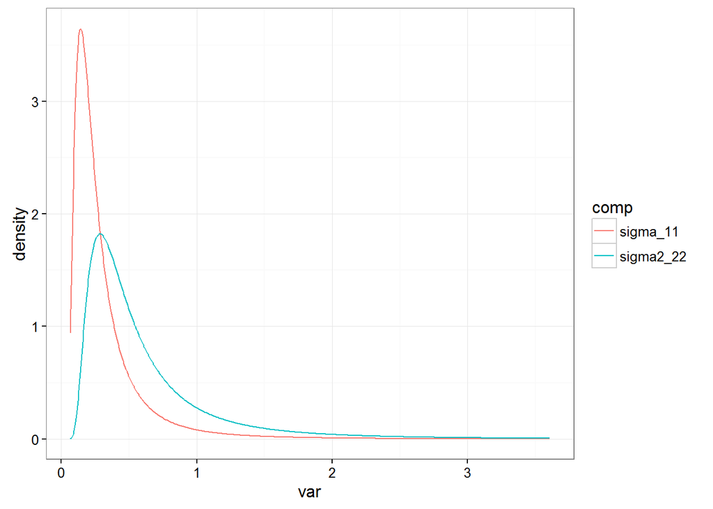

```r
ggplot(priordf.var, aes(var, density, col = comp)) +
  geom_line() +
  theme_bw()
```

## c) Correlacion

Visualizamos la distribucion marginal de la correlacion de la matriz $\Sigma$ empleando metodos numericos, pues la derivacion teorica es complicada.

Para esto, empleamos el siguienteresultado. Una matriz $A$ es tal que $A ~ invW(S, \nu)$ si y solo si $A^{-1} ~ W(S^{-1}, \nu)$.

De esta forma, generamos muestras de la correlacion o covarianzas de la siguiente forma:

```r
rinvWish <- function(n, S, nu, corr = TRUE) {
  invsample <- lapply(seq.int(n),
                   function(x) rwish(nu, solve(S)))
  sample <- lapply(invsample, solve)
  cov <- sapply(sample,
                function(x) x[1,2])
  if( corr ) {
    denom <- apply(sqrt(sapply(sample, diag)), 2, prod)
    stopifnot(abs(cov) < denom)
    cov <- cov/denom
  }

  return(cov)
}
```

El resultados empirico:

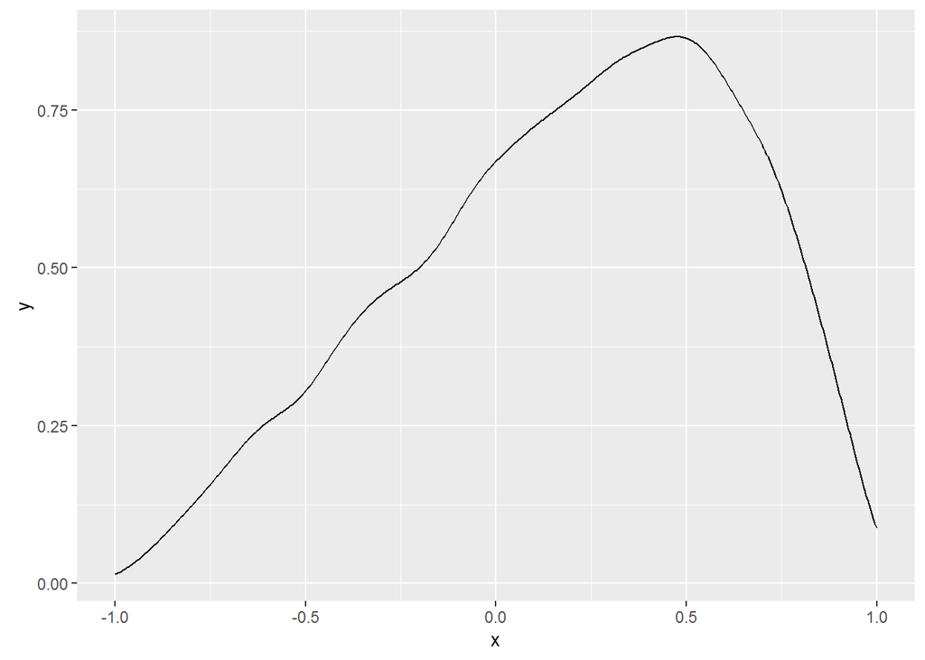

```r
N.sim <- 1e4
cor.smpl <- rinvWish(N.sim, S, nu, corr = TRUE)
ggplot(as.data.frame(density(cor.smpl, from = -1, to = 1)[1:2]),
       aes(x, y)) +
  geom_line()
```

## Referencias

- **Bishop** - Pattern Recognition and Machine Learning.